# Developing classification models to predict the success of bank telemarketing.

## 1. Introduction

The aim of this project is to develop classification models capable of accurately identifying customers willing to subscribe to long-term deposits based on their demographic and social characteristics. Additionally, we aim to assess the significance of these characteristics. By achieving these objectives, we could provide a valuable tool for banks to enhance their telemarketing efforts by focusing on customers more likely to meet the subscription criteria.

## 2. About the Dataset

The original data was collected from 2008 to 2010 from a Portuguese retail bank by Sergio Moro in his research paper “A data-driven approach to predict the success of bank telemarketing”. It contains 41188 observations with 21 variables related to bank client, product, and social-economic attributes. The dataset was obtained from UCI Machine Learning Repository for our analysis.

- Original research paper: https://www.sciencedirect.com/science/article/abs/pii/S016792361400061X?via%3Dihub#preview-section-cited-by
- Dataset retrieving source: https://archive.ics.uci.edu/dataset/222/bank+marketing

```r
# Read the dataset into a data frame
bank.data<- read.csv("/Users/iankim/Desktop/ST312 submission/Bank full data imported.csv")
# Display the first 10 observations
head(bank.data, 10)
```

```
##    age         job marital           education default housing loan   contact
## 1   56   housemaid married            basic.4y      no      no   no telephone
## 2   57    services married         high.school unknown      no   no telephone
## 3   37    services married         high.school      no     yes   no telephone
## 4   40      admin. married            basic.6y      no      no   no telephone
## 5   56    services married         high.school      no      no  yes telephone
## 6   45    services married            basic.9y unknown      no   no telephone
## 7   59      admin. married professional.course      no      no   no telephone
## 8   41 blue-collar married             unknown unknown      no   no telephone
## 9   24  technician  single professional.course      no     yes   no telephone
## 10  25    services  single         high.school      no     yes   no telephone
##    month day_of_week duration campaign pdays previous    poutcome emp.var.rate
## 1    may         mon      261        1   999        0 nonexistent          1.1
## 2    may         mon      149        1   999        0 nonexistent          1.1
## 3    may         mon      226        1   999        0 nonexistent          1.1
```

[output cut: 18 more lines]

Let’s have a look at the variables, and the number of observations in this dataset.

```r
# Get a list of variable names
variables_list <- names(bank.data)
# Check the number of observations
num_rows <- nrow(bank.data)
# Display the list of variable names
print(variables_list)
```

```
##  [1] "age"            "job"            "marital"        "education"
##  [5] "default"        "housing"        "loan"           "contact"
##  [9] "month"          "day_of_week"    "duration"       "campaign"
## [13] "pdays"          "previous"       "poutcome"       "emp.var.rate"
## [17] "cons.price.idx" "cons.conf.idx"  "euribor3m"      "nr.employed"
## [21] "deposit"
```

```r
print(num_rows)
```

```
## [1] 41188
```

There are 21 variables and 41188 observations.

Let’s take a look at the description of each variable.

```r
bank.data.schema<- read.csv("/Users/iankim/Library/Containers/com.microsoft.Excel/Data/Desktop/ST312 submission/bank_data_schema2.csv", row.names = "Variable")
bank.data.schema
```

```
##                                                                                                Definition
## age                                                                                                   Age
## job                                                                                                   Job
## marital                                                                                   Marital status
## education                                                                     Level of education received
## default                                                                     Whether has credit in default
## housing                                                                          Whether has housing loan
## loan                                                                            Whether has personal loan
## contact                                                                        Contact communication type
## month                                                                                  Last contact month
## day_of_week                                                                  Last contact day of the week
## duration                                                                            Last contact duration
## campaign                            Number of contacts performed during this campaign and for this client
## pdays          Number of days that passed by after the client was last contacted from a previous campaign
## previous                             Number of contacts performed before this campaign and for this clien
## poutcome                                                       outcome of the previous marketing campaign
## emp.var.rate                                              employment variation rate — quarterly indicator
## cons.price.idx                                                   consumer price index — monthly indicator
## cons.conf.idx                                               consumer confidence index — monthly indicator
## euribor3m                                                          euribor 3 month rate — daily indicator
## nr.employed                                                     number of employees — quarterly indicator
## deposit                                                Whether the customer has subscribed a term deposit
```

- Variables from “age” to “loan” indicate personal attributes of the client.
- Variables from “contact” to “poutcome” indicate attributes regarding the bank’s current and previous telemarketing campaigns.
- Variables from “emp.var.rate” to “nr.employed” indicate the social and economic attributes.
- “deposit” which indicates whether the customer has subscribed a term deposit will be the response variable for our analysis.

## 3. Exploratory Data Analysis (EDA)

### 3.1 Identifying the class distribution of the response variable

Class distribution of the response variable was initially checked to identify if the dataset was balanced.

```r
# Get counts for 'deposit'
deposit_counts <- table(bank.data$deposit)

# Print counts
print(deposit_counts)
```

```
##
##    no   yes
## 36548  4640
```

```r
# Calculate percentages
deposit_percentages <- prop.table(deposit_counts) * 100

# Print percentages
print(deposit_percentages)
```

```
##
##       no      yes
## 88.73458 11.26542
```

- The dataset is imbalanced, as only 4640 (11.27%) records are related with successes of customers subscribing to deposit.
- As imbalanced data could be problematic when developing the models, this can be resolved in the Data Pre-processing section later on.

### 3.2 Univariate Exploratory Analysis of Categorical Variables

Univariate EDAs can be conducted to identify the relationships with “deposit” and some of the categorical variables that may have a significant effect on “deposit” by intuition. E.g., “job”, “marital”, and “poutcome”.

```r
# Importing necessary libraries
library(ggplot2)
library(car)
library(dplyr)
library(tidyr)
```

Let’s explore the relationship between “job” and “deposit”.

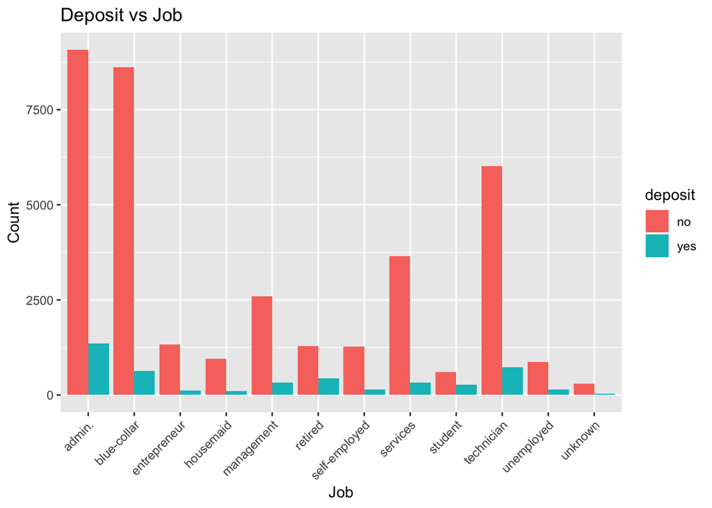

```r
bank.data$job<- as.factor(bank.data$job)
bank.data$deposit<- as.factor(bank.data$deposit)

p1<- ggplot(bank.data, aes(x = job, fill = deposit)) +
  geom_bar(position = "dodge") +
  labs(title = "Deposit vs Job", x = "Job", y = "Count")
p1 <- p1 + theme(axis.text.x = element_text(angle = 45, hjust = 1))
p1
```

- The bar chart illustrates that job categories like admin, blue-collar, and technician exhibit both the highest “yes” and “no” rates for ‘deposit.’
- However, this observation may be attributed to the fact that a substantial proportion of clients fall within these occupation categories.
- Consequently, it becomes challenging to make a definitive association.

To gain further insights, we can explore the percentage of clients making deposits within each ‘job’ category.

```r
# Calculate the percentage of 'deposit' for each category of 'job'
percentage_by_job <- bank.data %>%
  group_by(job, deposit) %>%
  summarise(count = n()) %>%
  group_by(job) %>%
  mutate(percentage = count / sum(count) * 100) %>%
  select(job, deposit, percentage)
```

[output not shown]

```r
# Print the result
print(percentage_by_job)
```

```
## # A tibble: 24 × 3
## # Groups:   job [12]
##    job          deposit percentage
##    <fct>        <fct>        <dbl>
##  1 admin.       no           87.0
##  2 admin.       yes          13.0
##  3 blue-collar  no           93.1
##  4 blue-collar  yes           6.89
##  5 entrepreneur no           91.5
##  6 entrepreneur yes           8.52
##  7 housemaid    no           90
##  8 housemaid    yes          10
##  9 management   no           88.8
## 10 management   yes          11.2
## # … with 14 more rows
```

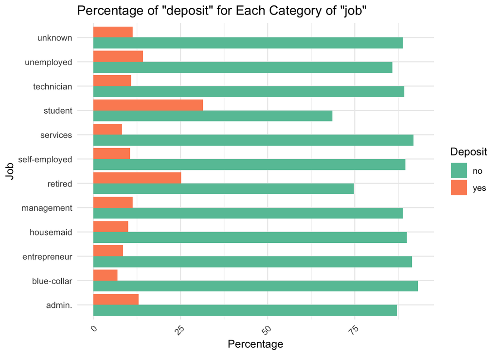

```r
# Create a bar plot
ggplot(percentage_by_job, aes(x = job, y = percentage, fill = deposit)) +
  geom_bar(stat = 'identity', position = 'dodge') +
  labs(title = 'Percentage of "deposit" for Each Category of "job"',
       x = 'Job', y = 'Percentage') +
  theme_minimal() +
  theme(axis.text.x = element_text(angle = 45, hjust = 1)) +
  scale_fill_manual(values = c('#66c2a5', '#fc8d62'), name = 'Deposit') +
  coord_flip()
```

- As expected, the percentage of clients making deposits is similar across all categories of ‘job’, which are mostly below 15%.
- Clients who are ‘retired’ and ‘student’ presented relatively higher rate of making deposits of 25.2% and 31.4% respectively.
- This could be easily assumed since clients in these categories are prone to saving up and have relatively limited income than clients in other job categories.
- Therefore, it was difficult to identify interesting associations between ‘job’ and ‘deposit’.

Now, let’s take a look at ‘marital’, which indicates the martial status of the clients.

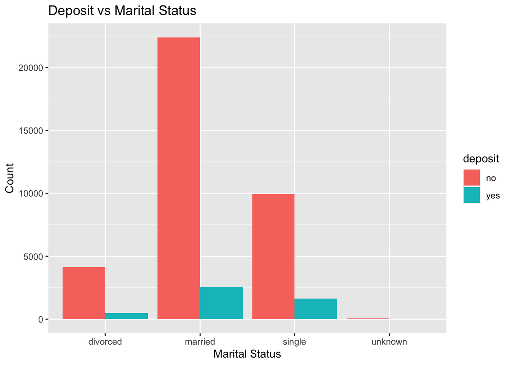

```r
bank.data$marital<- as.factor(bank.data$marital)

p2<- ggplot(bank.data, aes(x = marital, fill = deposit)) +
  geom_bar(position = "dodge") +
  labs(title = "Deposit vs Marital Status", x = "Marital Status", y = "Count")
p2
```

- Similar to the bar chart on the counts of ‘job’ vs ‘deposit’, it is ambiguous to identify a clear trend.
- We could try to plot the bar chart of percentages in each class of ‘marital’.

```r
# Calculate the percentage of 'deposit' for each category of 'marital'
percentage_by_marital <- bank.data %>%
  group_by(marital, deposit) %>%
  summarise(count = n()) %>%
  group_by(marital) %>%
  mutate(percentage = count / sum(count) * 100) %>%
  select(marital, deposit, percentage)
# Print the result
print(percentage_by_marital)
```

```
## # A tibble: 8 × 3
## # Groups:   marital [4]
##   marital  deposit percentage
##   <fct>    <fct>        <dbl>
## 1 divorced no            89.7
## 2 divorced yes           10.3
## 3 married  no            89.8
## 4 married  yes           10.2
## 5 single   no            86.0
## 6 single   yes           14.0
## 7 unknown  no            85
## 8 unknown  yes           15
```

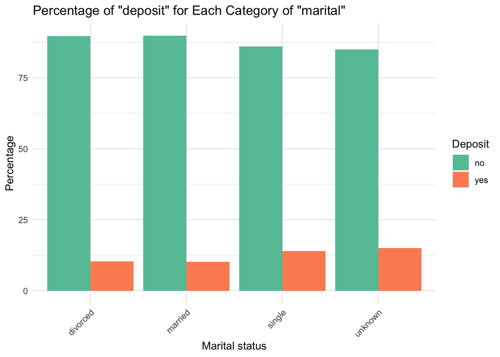

```r
# Create a bar plot
ggplot(percentage_by_marital, aes(x = marital, y = percentage, fill = deposit)) +
  geom_bar(stat = 'identity', position = 'dodge') +
  labs(title = 'Percentage of "deposit" for Each Category of "marital"',
       x = 'Marital status', y = 'Percentage') +
  theme_minimal() +
  theme(axis.text.x = element_text(angle = 45, hjust = 1)) +
  scale_fill_manual(values = c('#66c2a5', '#fc8d62'), name = 'Deposit')
```

The percentage of clients making deposits is similar across all categories of ‘marital’, which are generally below 15%. Hence, ‘marital’ is not likely to be a good predictor for ‘deposit’.

Now, let’s take a look at ‘poutcome’, where ‘poutcome’ indicates the outcome of the previous marketing campaign towards the current clients.

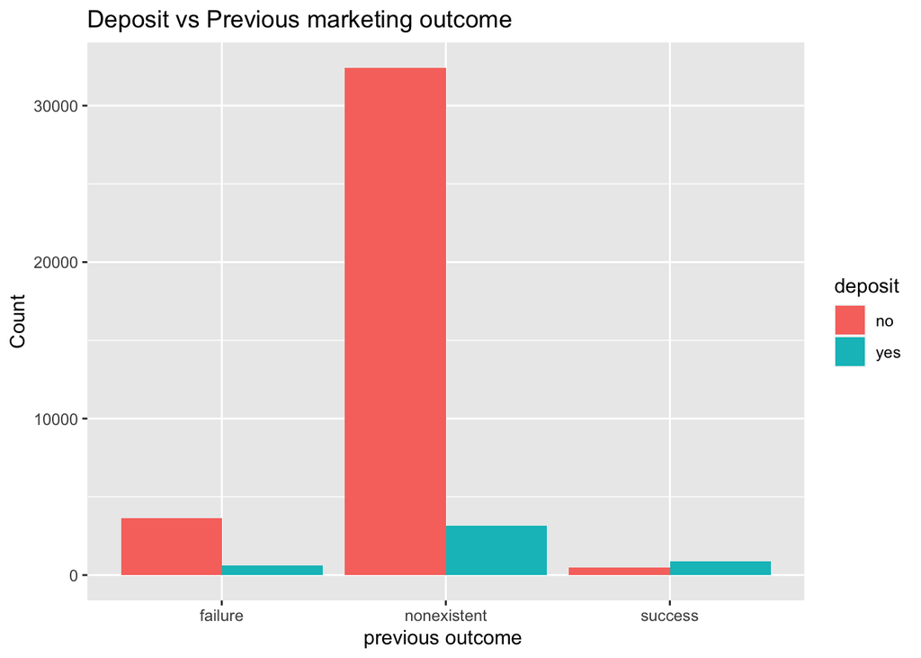

```r
bank.data$poutcome<- as.factor(bank.data$poutcome)
p3<- ggplot(bank.data, aes(x = poutcome, fill = deposit)) +
  geom_bar(position = "dodge") +
  labs(title = "Deposit vs Previous marketing outcome", x = "previous outcome ", y = "Count")
p3
```

- Based on the plots, it shows that the previous marketing campaign outcome did not exist for most current customers, which implies that most of them are new customers who have not been contacted earlier.
- Looking at the ‘success’ category, we could observe that the counts on ‘yes’ and ‘no’ of ‘deposit’ are not significantly different.

Let’s have a look at the percentages.

```r
# Calculate the percentage of 'deposit' for each category of 'poutcome'
percentage_by_poutcome <- bank.data %>%
  group_by(poutcome, deposit) %>%
  summarise(count = n()) %>%
  group_by(poutcome) %>%
  mutate(percentage = count / sum(count) * 100) %>%
  select(poutcome, deposit, percentage)
# Print the result
print(percentage_by_poutcome)
```

```
## # A tibble: 6 × 3
## # Groups:   poutcome [3]
##   poutcome    deposit percentage
##   <fct>       <fct>        <dbl>
## 1 failure     no           85.8
## 2 failure     yes          14.2
## 3 nonexistent no           91.2
## 4 nonexistent yes           8.83
## 5 success     no           34.9
## 6 success     yes          65.1
```

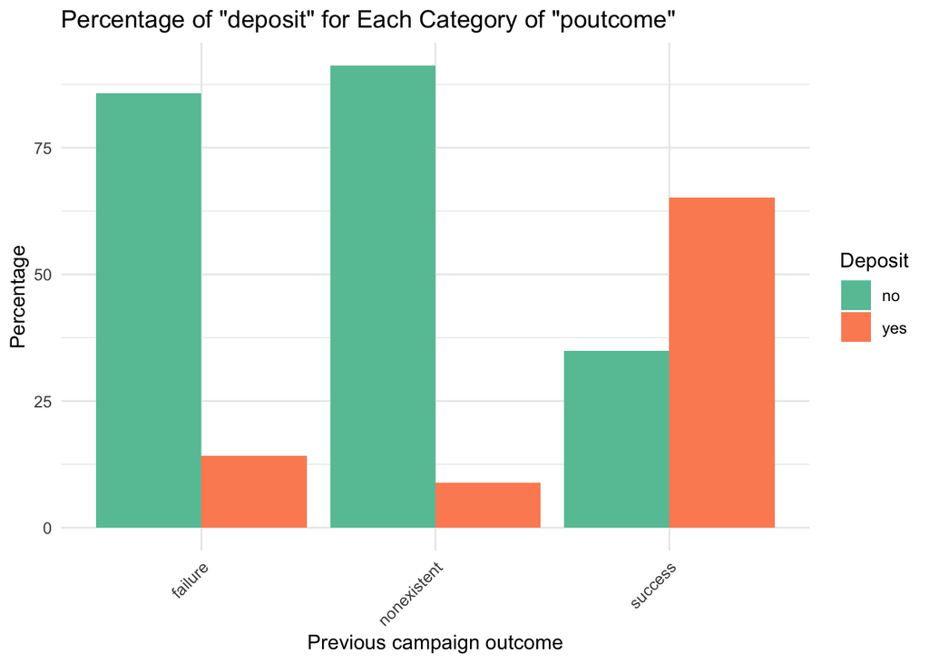

```r
# Create a bar plot
ggplot(percentage_by_poutcome, aes(x = poutcome, y = percentage, fill = deposit)) +
  geom_bar(stat = 'identity', position = 'dodge') +
  labs(title = 'Percentage of "deposit" for Each Category of "poutcome"',
       x = 'Previous campaign outcome', y = 'Percentage') +
  theme_minimal() +
  theme(axis.text.x = element_text(angle = 45, hjust = 1)) +
  scale_fill_manual(values = c('#66c2a5', '#fc8d62'), name = 'Deposit')
```

- Interestingly, we could identify that for the customers who had a successful outcome from the previous campaign, more than 65% of those customers has subscribed for a term deposit again.
- Such an observation implies that “poutcome” could be a strong predictor for the response variable.

### 3.3 Univariate Exploratory Analysis of Numerical Variables

Further univariate EDAs can be conducted to identify the relationships with “deposit” and some of the numerical variables that may have a significant effect on “deposit” by intuition. E.g., “duration”,“emp.var.rate”, “euribor3m”, and “age”.

Let’s start with ‘duration’, where ‘duration’ indicates the duration time of the last contact (telephone call) in seconds with the client.

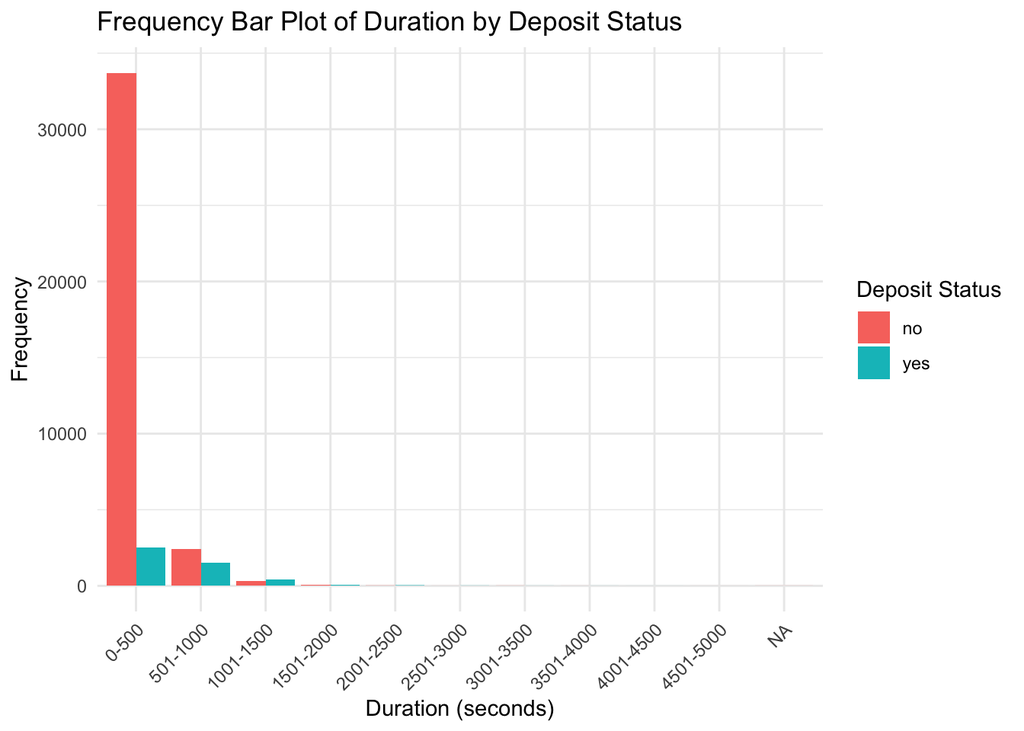

```r
p4<- ggplot(bank.data, aes(x = cut(duration, breaks = seq(0, 5000, 500)), fill = deposit)) +
  geom_bar(position = "dodge") +
  labs(title = "Frequency Bar Plot of Duration by Deposit Status",
       x = "Duration (seconds)",
       y = "Frequency",
       fill = "Deposit Status") +
  scale_x_discrete(labels = c("0-500", "501-1000", "1001-1500", "1501-2000", "2001-2500", "2501-3000", "3001-3500", "3501-4000", "4001-4500", "4501-5000"))+
theme_minimal() +
  theme(axis.text.x = element_text(angle = 45, hjust = 1))
p4
```

We can then look at the social-economic attributes.“emp.var.rate” is a quaterly indicator of employment variation rate, and “euribor3m” is a daily indicator of euribor 3 month rate.

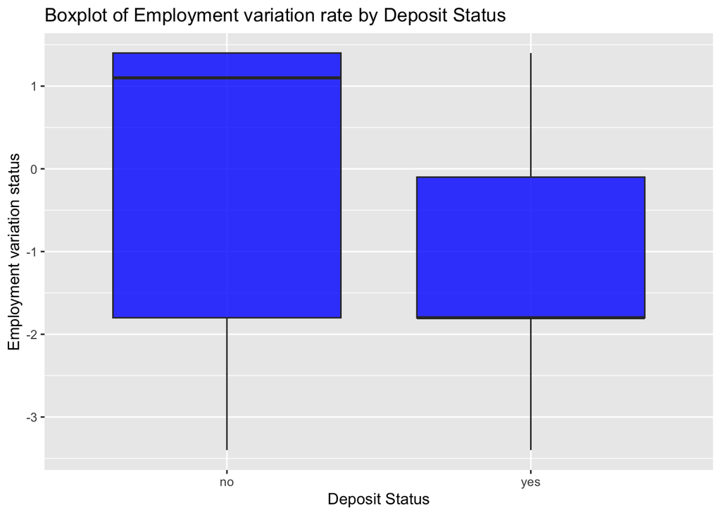

```r
p5<- ggplot(bank.data, aes(x = deposit, y = emp.var.rate)) +
  geom_boxplot(fill = "blue", alpha = 0.8) +
  labs(title = "Boxplot of Employment variation rate by Deposit Status",
       x = "Deposit Status",
       y = "Employment variation status")
p5
```

```r
# Choose a CRAN mirror (replace 'https://cran.r-project.org/' with your preferred mirror)
chooseCRANmirror(graphics = FALSE, ind = 1)

# Install and load the doBy package
install.packages("doBy")
library(doBy)
# Create a summary statistics
emp_summary_stats <- summaryBy(emp.var.rate ~ deposit, data = bank.data, FUN = function(x) c(mean = mean(x), sd = sd(x), min = min(x), max = max(x)))

# Print the result
print(emp_summary_stats)
```

```
##   deposit emp.var.rate.mean emp.var.rate.sd emp.var.rate.min emp.var.rate.max
## 1      no         0.2488755        1.482932             -3.4              1.4
## 2     yes        -1.2334483        1.623626             -3.4              1.4
```

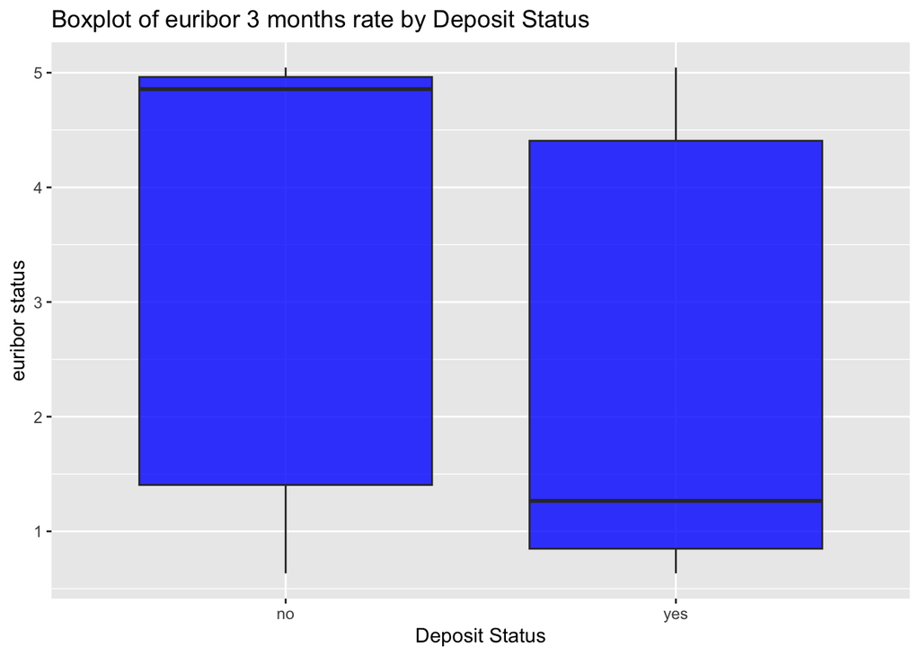

```r
p6<- ggplot(bank.data, aes(x = deposit, y = euribor3m)) +
  geom_boxplot(fill = "blue", alpha = 0.8) +
  labs(title = "Boxplot of euribor 3 months rate by Deposit Status",
       x = "Deposit Status",
       y = "euribor status")
p6
```

```r
# Create a summary statistics
eur_summary_stats <- summaryBy(euribor3m~ deposit, data = bank.data, FUN = function(x) c(mean = mean(x), sd = sd(x), min = min(x), max = max(x)))

# Print the result
print(eur_summary_stats)
```

```
##   deposit euribor3m.mean euribor3m.sd euribor3m.min euribor3m.max
## 1      no       3.811491     1.638187         0.634         5.045
## 2     yes       2.123135     1.742598         0.634         5.045
```

- The box plots and summary statistics for both “emp.var.rate” and “euribor3m” illustrated the big difference between the mean, median values of the “yes” and “no” deposit subscription outputs.
- Hence, these social-economic attributes seem to be influential in predicting the target variable “deposit”

Lastly, we could look into ‘age’.

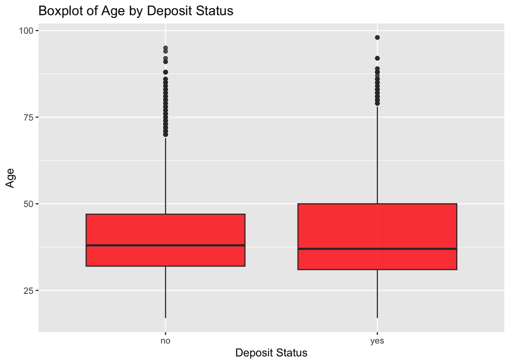

```r
p7<- ggplot(bank.data, aes(x = deposit, y = age)) +
  geom_boxplot(fill = "red", alpha = 0.8) +
  labs(title = "Boxplot of Age by Deposit Status",
       x = "Deposit Status",
       y = "Age")
p7
```

```r
# Create a summary statistics
age_summary_stats <- summaryBy(age~ deposit, data = bank.data, FUN = function(x) c(mean = mean(x), sd = sd(x), min = min(x), max = max(x)))

# Print the result
print(age_summary_stats)
```

```
##   deposit age.mean    age.sd age.min age.max
## 1      no 39.91119  9.898132      17      95
## 2     yes 40.91315 13.837476      17      98
```

Surprisingly, “age” seemed to be not necessarily influential, as the box plots showed a median age of around 38-40 for both “yes” and “no” classes of the response variable

### 3.4 Correlation matrix

Lastly, a correlation matrix can be created to check potential multicollinearity issues and to observe general correlation among the continuous independent variables.

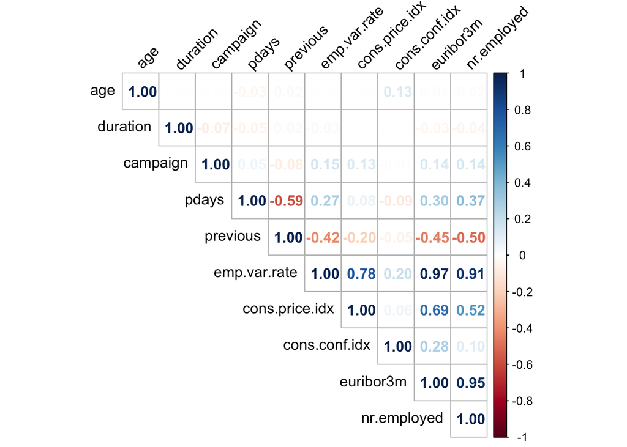

```r
library(corrplot)
# Generating a subset of the dataset only containing numeric variables
bank.data.numeric<- subset(bank.data, select =
                           -c(job,marital,education,default,housing,loan,contact,month,day_of_week,poutcome,deposit))
# Computing correlation matrix
corr_matrix <- cor(bank.data.numeric)

# Creating a correlation plot matrix
corrplot(corr_matrix, method = "number", type = "upper", tl.col = "black", tl.srt = 45)
```

- The correlation matrix indicates that “emp.var.rate”, “cons.price.idx”, “euribor3m” and “nr.employed” features have very high correlation.
- Specifically, “euribor3m” and “emp.var.rate” showed the highest correlation of 97%.
- Hence, some of these highly correlated variables could be potentially removed to avoid multicollinearity issues when building the model.

## 4. Data pre-processing

### 4.1 Checking missing values

- Checking missing values is important to ensure that the dataset is complete and free from missing or null values.
- This is because missing values can lead to biased or incorrect results in the regression analysis later on.

```r
any(is.na(bank.data))
```

```
## [1] FALSE
```

There is no missing value in the dataframe, hence there is no need to handle data in this regard.

### 4.2 Removing “duration”

```r
# Remove the 'duration' column
bank.data <- subset(bank.data, select = -duration)
```

### 4.3 Dealing with imbalanced data

As discussed in the EDA, the dataset was highly imbalanced in regards to the response variable.

```r
# Get counts for 'deposit'
deposit_counts <- table(bank.data$deposit)

# Print counts
print(deposit_counts)
```

```
##
##    no   yes
## 36548  4640
```

```r
# Calculate percentages
deposit_percentages <- prop.table(deposit_counts) * 100

# Print percentages
print(deposit_percentages)
```

```
##
##       no      yes
## 88.73458 11.26542
```

Only 4640 (11.27%) records show the successes of customers subscribing to deposit.

This is problematic since it could lead to severe reduction in accuracy of ML model we are attempting to build, as the highly unequal distribution in dependent variable of the training data makes the ML algorithm to become biased towards the majority class.

- To tackle this unequal distribution, we could generate syenthetic data using ROSE (Random Over Sampling Examples) package in R.
- ROSE uses k-nearest neighbors to create synthetic instances for the minority class, aiming to balance the class distribution.

We make the dataset suitable for ROSE

```r
# To use ROSE, variables defined character should be converted to factor
bank.data[] <- lapply(bank.data, function(x) if (is.character(x)) as.factor(x) else x)
```

### 4.4 Splitting traing & testing data and applying ROSE

We first divide the data in accordance with the recommended 8:2 ratio, which is considered optimal for training ML models

```r
# Randomly splitting the data into training and testing datasets
set.seed(123)
train_index <- sample(nrow(bank.data), round(nrow(bank.data)*0.8))
bank.train <- bank.data[train_index, ]
bank.test <- bank.data[-train_index, ]
```

```r
table(bank.train$deposit)
```

```
##
##    no   yes
## 29185  3765
```

```r
table(bank.test$deposit)
```

```
##
##   no  yes
## 7363  875
```

We then apply ROSE to the training data

```r
library(ROSE)
# Use the ROSE function to create a new training dataset with synthetic data
bank.train.rose <- ROSE(deposit ~ ., data = bank.train, seed = 123, N = nrow(bank.train)*2)$data
new_deposit_counts<- table(bank.train.rose$deposit)
new_deposit_counts
```

```
##
##    no   yes
## 33276 32624
```

```r
# Calculate percentages
new_deposit_percentages <- prop.table(new_deposit_counts) * 100

# Print percentages
print(new_deposit_percentages)
```

```
##
##       no      yes
## 50.49469 49.50531
```

Hence, we have resolved the imbalanced class distribution, as 49.5% of records indicate the successes of customers subscribing to deposit.

## 5. Model Development

To achieve our research objectives, we can develop two different classification models: Logistic Regression model and Decision Tree model.

### 5.1 Logistic Regression Model

We will develop a logistic regression model, which is a supervised learning model that is commonly used to predict the probability of a binary event occurring.

#### Applying Stepwise Selection

Stepwise selection of minimizing the Akaike Information Criterion (AIC) will be used to select the significant variables in the model.

- Stepwise selection performs iterative process of selecting the optimal subset of variables for inclusion in a model.
- AIC (Akaike Information Criterion): A measure of the relative quality of statistical models that is optimal when minimized
- Backward Stepwise Selection will be conducted where we start with the full model (including all variables) and iteratively remove variables one at a time.

We first build a model including all variables.

```r
# Initial logistic model
model1<- glm(deposit~., data = bank.train.rose,family=binomial(link="logit"))
```

Apply Stepwise Selection.

```r
library(MASS) # required library for Stepwise selection
# applying the step function
stepAIC(model1, direction = "backward", trace = FALSE)
```

```
##
## Call:  glm(formula = deposit ~ age + job + marital + education + default +
##     housing + contact + month + day_of_week + campaign + pdays +
##     previous + poutcome + emp.var.rate + cons.price.idx + cons.conf.idx +
##     euribor3m + nr.employed, family = binomial(link = "logit"),
##     data = bank.train.rose)
##
## Coefficients:
##                  (Intercept)                           age
##                    8.939e+00                     2.678e-03
##               jobblue-collar               jobentrepreneur
##                   -4.040e-02                     8.934e-02
##                 jobhousemaid                 jobmanagement
##                   -8.333e-02                     4.582e-02
##                   jobretired              jobself-employed
##                    4.057e-01                    -6.685e-02
##                  jobservices                    jobstudent
##                   -5.638e-02                     5.524e-01
##                jobtechnician                 jobunemployed
##                    6.089e-02                     2.002e-01
##                   jobunknown                maritalmarried
##                   -9.764e-02                    -3.057e-02
##                maritalsingle                maritalunknown
##                    5.764e-02                     3.267e-01
##            educationbasic.6y             educationbasic.9y
##                    9.977e-02                     1.765e-01
##         educationhigh.school           educationilliterate
##                    1.162e-01                     8.191e-01
## educationprofessional.course    educationuniversity.degree
##                    1.028e-01                     2.552e-01
##             educationunknown                defaultunknown
##                    2.319e-01                    -2.710e-01
##                   defaultyes                housingunknown
##                   -1.076e+01                    -1.920e-01
##                   housingyes              contacttelephone
##                   -2.390e-02                    -3.762e-01
##                     monthaug                      monthdec
##                   -1.801e-01                     4.200e-01
##                     monthjul                      monthjun
##                    1.958e-01                     1.588e-01
```

[output cut: 9 more lines]

```
##                    1.042e-01                    -4.113e-02
##                        pdays                      previous
##                   -3.263e-04                     8.218e-02
##          poutcomenonexistent               poutcomesuccess
##                    4.254e-01                     1.540e+00
##                 emp.var.rate                cons.price.idx
##                   -1.475e-01                     1.257e-01
##                cons.conf.idx                     euribor3m
##                    2.157e-02                    -1.299e-01
##                  nr.employed
##                   -3.804e-03
##
## Degrees of Freedom: 65899 Total (i.e. Null);  65849 Residual
## Null Deviance:       91350
## Residual Deviance: 71760     AIC: 71870
```

Hence, this is the model with predictors selected from stepwise selection.

```r
stepmodel<- glm(deposit ~ age + job + marital + education + default +
    housing + contact + month + day_of_week + campaign + pdays +
    previous + poutcome + emp.var.rate + cons.price.idx + cons.conf.idx +
    euribor3m + nr.employed, family = binomial(link = "logit"),
    data = bank.train.rose)
```

#### Examining statistical significance of the predictors

We can then assess the p-value of each predictor.

- The p-value is a statistical measure that helps determine the significance of a predictor’s contribution to the model.
- In the common practice, if a predictor has the p-value less than or equal to 0.05, it is considered statistically significant.

```r
summary(stepmodel)
```

```
##
## Call:
## glm(formula = deposit ~ age + job + marital + education + default +
##     housing + contact + month + day_of_week + campaign + pdays +
##     previous + poutcome + emp.var.rate + cons.price.idx + cons.conf.idx +
##     euribor3m + nr.employed, family = binomial(link = "logit"),
##     data = bank.train.rose)
##
## Deviance Residuals:
##     Min       1Q   Median       3Q      Max
## -3.0496  -0.8859  -0.5041   0.8573   2.2688
##
## Coefficients:
##                                Estimate Std. Error z value Pr(>|z|)
## (Intercept)                   8.939e+00  2.461e+00   3.632 0.000281 ***
## age                           2.678e-03  9.174e-04   2.919 0.003507 **
## jobblue-collar               -4.040e-02  3.425e-02  -1.180 0.238197
## jobentrepreneur               8.934e-02  5.183e-02   1.724 0.084766 .
## jobhousemaid                 -8.333e-02  6.603e-02  -1.262 0.206960
## jobmanagement                 4.582e-02  3.922e-02   1.168 0.242680
## jobretired                    4.057e-01  5.050e-02   8.033 9.51e-16 ***
## jobself-employed             -6.685e-02  5.290e-02  -1.264 0.206382
## jobservices                  -5.638e-02  3.770e-02  -1.496 0.134726
## jobstudent                    5.524e-01  6.088e-02   9.074  < 2e-16 ***
## jobtechnician                 6.089e-02  3.189e-02   1.910 0.056186 .
## jobunemployed                 2.002e-01  6.028e-02   3.321 0.000897 ***
## jobunknown                   -9.764e-02  1.168e-01  -0.836 0.403369
## maritalmarried               -3.057e-02  2.987e-02  -1.024 0.306057
## maritalsingle                 5.764e-02  3.366e-02   1.712 0.086827 .
## maritalunknown                3.267e-01  1.926e-01   1.696 0.089847 .
## educationbasic.6y             9.977e-02  5.270e-02   1.893 0.058349 .
## educationbasic.9y             1.765e-01  4.094e-02   4.311 1.63e-05 ***
## educationhigh.school          1.162e-01  4.144e-02   2.804 0.005042 **
## educationilliterate           8.191e-01  3.799e-01   2.156 0.031074 *
## educationprofessional.course  1.028e-01  4.595e-02   2.237 0.025283 *
## educationuniversity.degree    2.552e-01  4.198e-02   6.079 1.21e-09 ***
## educationunknown              2.319e-01  5.569e-02   4.164 3.13e-05 ***
## defaultunknown               -2.710e-01  2.657e-02 -10.199  < 2e-16 ***
## defaultyes                   -1.076e+01  6.549e+01  -0.164 0.869540
## housingunknown               -1.920e-01  6.450e-02  -2.976 0.002919 **
```

[output cut: 20 more lines]

```
## emp.var.rate                 -1.475e-01  1.073e-02 -13.748  < 2e-16 ***
## cons.price.idx                1.257e-01  2.167e-02   5.802 6.56e-09 ***
## cons.conf.idx                 2.157e-02  2.221e-03   9.712  < 2e-16 ***
## euribor3m                    -1.299e-01  9.822e-03 -13.223  < 2e-16 ***
## nr.employed                  -3.804e-03  2.011e-04 -18.920  < 2e-16 ***
## ---
## Signif. codes:  0 '***' 0.001 '**' 0.01 '*' 0.05 '.' 0.1 ' ' 1
##
## (Dispersion parameter for binomial family taken to be 1)
##
##     Null deviance: 91350  on 65899  degrees of freedom
## Residual deviance: 71763  on 65849  degrees of freedom
## AIC: 71865
##
## Number of Fisher Scoring iterations: 10
```

To mitigate overfitting resulting from the high complexity of the model, we will exclude every predictor with categories (dummy variables) that lack statistical significance.

```r
stepmodel<- glm(deposit ~ age + contact + campaign + pdays +
    previous + poutcome + emp.var.rate + cons.price.idx + cons.conf.idx +
    euribor3m + nr.employed, family = binomial(link = "logit"),
    data = bank.train.rose)
```

```r
summary(stepmodel)
```

```
##
## Call:
## glm(formula = deposit ~ age + contact + campaign + pdays + previous +
##     poutcome + emp.var.rate + cons.price.idx + cons.conf.idx +
##     euribor3m + nr.employed, family = binomial(link = "logit"),
##     data = bank.train.rose)
##
## Deviance Residuals:
##     Min       1Q   Median       3Q      Max
## -2.7226  -0.8802  -0.5618   0.9301   2.3096
##
## Coefficients:
##                       Estimate Std. Error z value Pr(>|z|)
## (Intercept)         -7.0779300  2.2293063  -3.175  0.00150 **
## age                  0.0018944  0.0007055   2.685  0.00725 **
## contacttelephone    -0.6458217  0.0235202 -27.458  < 2e-16 ***
## campaign            -0.0379633  0.0036771 -10.324  < 2e-16 ***
## pdays               -0.0003298  0.0000554  -5.953 2.64e-09 ***
## previous             0.0891395  0.0224047   3.979 6.93e-05 ***
## poutcomenonexistent  0.5424745  0.0391315  13.863  < 2e-16 ***
## poutcomesuccess      1.6459024  0.0759638  21.667  < 2e-16 ***
## emp.var.rate        -0.1847559  0.0100119 -18.454  < 2e-16 ***
## cons.price.idx       0.3102112  0.0195889  15.836  < 2e-16 ***
## cons.conf.idx        0.0271520  0.0016753  16.208  < 2e-16 ***
## euribor3m           -0.1357344  0.0093124 -14.576  < 2e-16 ***
## nr.employed         -0.0040053  0.0001883 -21.275  < 2e-16 ***
## ---
## Signif. codes:  0 '***' 0.001 '**' 0.01 '*' 0.05 '.' 0.1 ' ' 1
##
## (Dispersion parameter for binomial family taken to be 1)
##
##     Null deviance: 91350  on 65899  degrees of freedom
## Residual deviance: 74345  on 65887  degrees of freedom
## AIC: 74371
##
## Number of Fisher Scoring iterations: 5
```

Now every predictor is statistically significant, and the model is more simplified.

#### Examining Multicollinearity

Now that we have checked the statistical significance of the predictors, we can examine multicollinearty among them.

- Multicollinearity refers to the presence of high correlations between predictor variables in a regression model. It can cause issues in the estimation of coefficients and lead to unstable and unreliable results.
- Multicollinearity can be examined via VIF (Variance Inflation Factor). VIF measures how much the variance of an estimated regression coefficient increases if the predictors are correlated.
- VIF values greater than 5 are often considered indicative of multicollinearity.

```r
library(car)
vif(stepmodel)
```

```
##                    GVIF Df GVIF^(1/(2*Df))
## age            1.013181  1        1.006569
## contact        1.390325  1        1.179120
## campaign       1.020495  1        1.010195
## pdays          2.148159  1        1.465660
## previous       2.449169  1        1.564982
## poutcome       4.682836  2        1.471049
## emp.var.rate   4.081525  1        2.020278
## cons.price.idx 2.166279  1        1.471828
## cons.conf.idx  1.154287  1        1.074377
## euribor3m      4.237982  1        2.058636
## nr.employed    3.208890  1        1.791337
```

No concerns regarding multicollinearity was found.

Now that our model is finalized, let’s see how the model performs on the testing data.

```r
# Make predictions on the testing data
predictions <- predict(stepmodel, newdata = bank.test, type = "response")

# Convert predicted probabilities to binary predictions (0 or 1)
predicted_classes <- ifelse(predictions > 0.5, 1, 0)

# Compare predicted classes with actual classes
conf_matrix <- table(predicted_classes, bank.test$deposit)

# Calculate accuracy rate
accuracy <- sum(diag(conf_matrix)) / sum(conf_matrix)
cat("Accuracy Rate:", accuracy, "\n")
```

```
## Accuracy Rate: 0.7608643
```

Hence, our final logistic regression model has the accuracy rate of 76.1%.

### 5.2 Decision Tree Model

We will also develop a decision tree model , which is a supervised learning model used in classification task through the algorithm of building tree-like model by recursively splitting the training data based on the most informative features.

```r
library(tree)

# First tree model
tree.m<- tree(deposit~., data=bank.train.rose)
summary(tree.m)
```

```
##
## Classification tree:
## tree(formula = deposit ~ ., data = bank.train.rose)
## Variables actually used in tree construction:
## [1] "pdays"     "euribor3m" "month"     "previous"
## Number of terminal nodes:  7
## Residual mean deviance:  0.7524 = 49580 / 65890
## Misclassification error rate: 0.1565 = 10312 / 65900
```

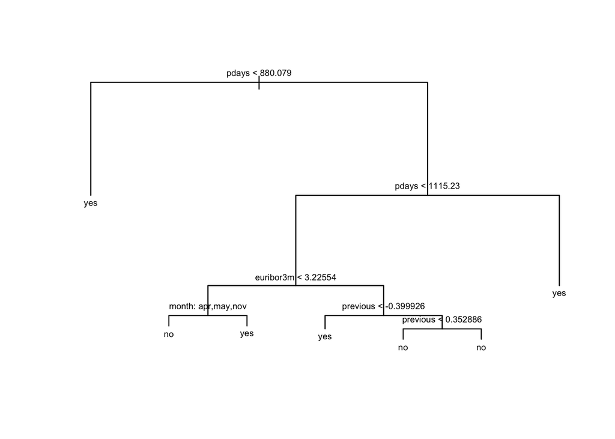

```r
plot(tree.m)
text(tree.m,pretty=0, cex=0.6)
```

```r
summary(tree.m)
```

```
##
## Classification tree:
## tree(formula = deposit ~ ., data = bank.train.rose)
## Variables actually used in tree construction:
## [1] "pdays"     "euribor3m" "month"     "previous"
## Number of terminal nodes:  7
## Residual mean deviance:  0.7524 = 49580 / 65890
## Misclassification error rate: 0.1565 = 10312 / 65900
```

- The variables used in tree construction are “pdays”, “euribor3m”, “previous”, and “month”.
- The model has 7 terminal nodes
- Misclassification error rate: 0.1565

#### Pruning the decision tree model

Decision trees have a tendency to become overly complex and to overfit leading to poor performance on new, unseen data. Pruning is a technique to control the complexity of the tree by removing branches that do not contribute significantly to improving the model’s performance.

- Pruning involves growing a large tree and then selectively removing branches. - Cross-validation helps assess the performance of the pruned tree on multiple subsets of the data, providing a more reliable estimate of its generalization ability.

We apply 10-fold cross-validation to find the optimal tree model.

```r
# Applying cross-validation
tree_cv = cv.tree(tree.m,FUN=prune.misclass)
tree_cv$size
```

```
## [1] 7 6 5 3 2 1
```

```r
tree_cv$dev
```

```
## [1] 10225 10225 10907 12757 19649 32624
```

- Tree models with 7,6,5,3,2,1 terminal nodes were found
- They correspond to 10225, 10225, 10907, 12757, 19649, 32624 misclassification occasions
- The minimum cv-misclassification value is 10225, corresponding to 7 or 6 terminal nodes

Since a tree model with less terminal nodes are generally easier to interpret, less prone to overfitting, and faster to compute, the pruned tree model with 6 terminal nodes can be considered as our final tree model.

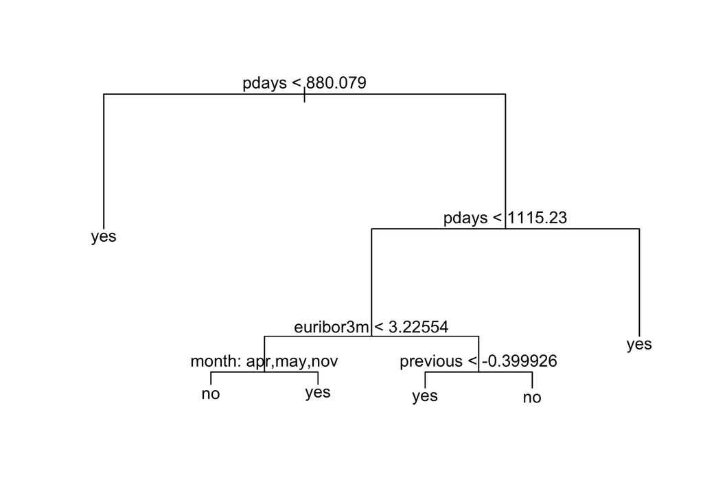

```r
# Generating fianl pruned tree model
tree.final<- prune.misclass(tree.m, best=6)
plot(tree.final)
text(tree.final, pretty=0)
```

```r
summary(tree.final)
```

```
##
## Classification tree:
## snip.tree(tree = tree.m, nodes = 27L)
## Variables actually used in tree construction:
## [1] "pdays"     "euribor3m" "month"     "previous"
## Number of terminal nodes:  6
## Residual mean deviance:  0.7768 = 51190 / 65890
## Misclassification error rate: 0.1565 = 10312 / 65900
```

We can then test the accuracy of our final tree model.

```r
# Make predictions on the training data
tree_predictions <- predict(tree.final, newdata = bank.test, type = "class")

# Create a confusion matrix
tree_conf_matrix <- table(tree_predictions, bank.test$deposit)

# Calculate accuracy rate
tree_accuracy <- sum(diag(tree_conf_matrix)) / sum(tree_conf_matrix)
cat("Accuracy Rate:", tree_accuracy, "\n")
```

```
## Accuracy Rate: 0.881646
```

Our final tree model has the accuracy rate of 88.2%.

## 6. Model performance evaluation

This report aims to build a classification model for accurately identifying customers willing to make deposits, while also assessing the significance of demographic and socio-economic features in the model. The ultimate goal is to optimize the bank’s telemarketing strategy. - To achieve this objective, relying solely on classifier accuracy is deemed inadequate. - Therefore, various model performance evaluation criteria have been employed, taking into account business considerations.

### 6.1 Recall as the Evaluation Criterion

In the business perspective, there were two types of major errors that the model could make,

- Predicting a customer would make deposit but they actually do not (False Positive) which could lead to loss of resources
- Predicting a customer would not make deposit but they actually do (False Negative) which could lead to loss of potential profits.

As the bank’s main objective is to maximize profits, the ideal classifier model should be able to minimize the loss of potential profits. Hence, we can consider that Recall (TP/(TP+FN)), an indicator of False Negative rate, could be an appropriate metric to evaluate the performance of our models.

#### Calculating Recall rate on the final logistic regression model

```r
# conf_matrix = confusion matrix for logistic model

# Extract values from the confusion matrix
true_positives <- conf_matrix[2, 2]
false_negatives <- conf_matrix[2, 1]

# Calculate recall
recall <- true_positives / (true_positives + false_negatives)
cat("Recall:", recall, "\n")
```

```
## Recall: 0.2608126
```

#### Calculating Recall rate on the final decision tree model

```r
# tree_conf_matrix = confusion matrix for logistic model

# Extract values from the confusion matrix
tree_true_positives <- tree_conf_matrix[2, 2]
tree_false_negatives <- tree_conf_matrix[2, 1]

# Calculate recall
tree_recall <- tree_true_positives / (tree_true_positives + tree_false_negatives)
cat("Recall:", tree_recall, "\n")
```

```
## Recall: 0.4466951
```

### 6.2 ROC AUC as the Evaluation Criterion

ROC (Receiving Operating Characteristics) curve is commonly used as a performance measurement of a classifier model at various threshold settings. AUC (Area Under the Curve) of the ROC curve indicates how much the model is capable of distinguishing between classes.

- The ROC plots also show the trade-offs between specificity and sensitivity (Recall) at every possible threshold.
- The higher the ROC AUC is, the better the model is at correctly classifying overall.

#### ROC AUC of the final logistic regression model

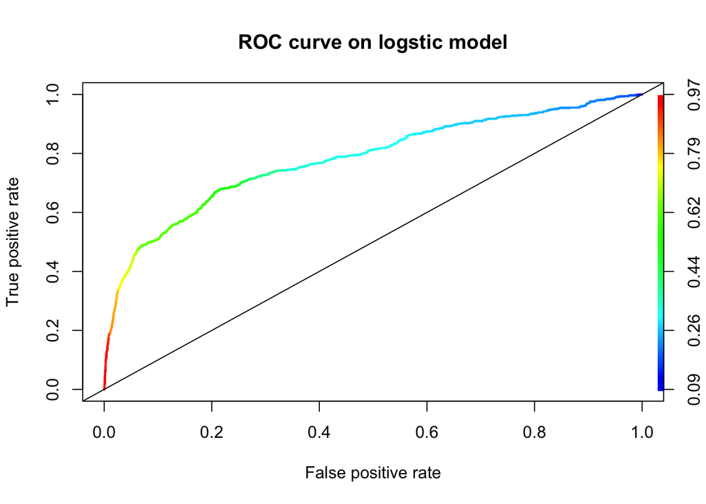

```r
library(ROCR)

#calculating the predicted probability for 'Yes' using the test data
prob.log = predict(stepmodel, bank.test, type = "response")

# ROC curve for the final logistic regression model
pred.log = prediction(prob.log, bank.test$deposit)
log.roc = performance(pred.log,measure="tpr", x.measure="fpr")
plot(log.roc, lwd=2, colorkey=T, colorize=T, main="ROC curve on logstic model")
abline(0,1)
```

```r
#evaluating the performance by calculating the area under the ROC curve
performance(pred.log, measure="auc")@y.values
```

```
## [[1]]
## [1] 0.7802394
```

#### ROC AUC of the final decision tree model

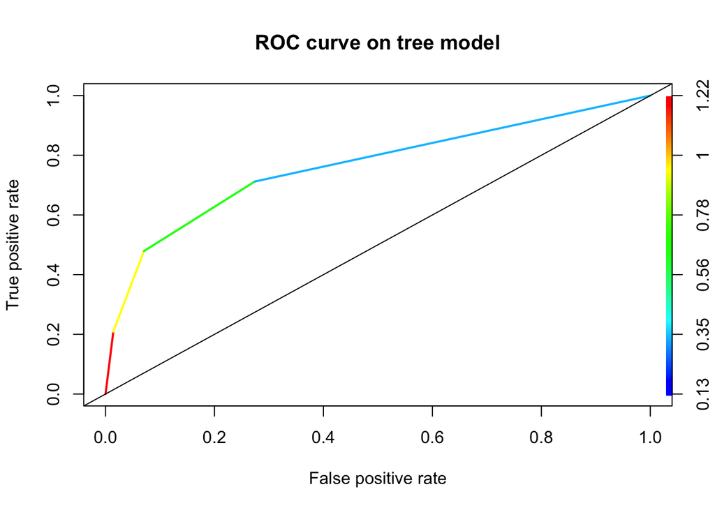

```r
library(ROCR)

#calculating the predicted probability for 'Yes' using the test data
prob.tree = predict(tree.final, bank.test, type = "vector")[,2]

# ROC curve for the final tree regression model
pred.tree = prediction(prob.tree, bank.test$deposit)
tree.roc = performance(pred.tree,measure="tpr", x.measure="fpr")
plot(tree.roc, lwd=2, colorkey=T, colorize=T, main="ROC curve on tree model")
abline(0,1)
```

```r
#evaluating the performance by calculating the area under the ROC curve
performance(pred.tree, measure="auc")@y.values
```

```
## [[1]]
## [1] 0.7634828
```

- The logistic regression model demonstrates the ROC AUC score of 0.78.
- The decision tree model demonstrates the ROC AUC score of 0.763.

## 7. Conclusion

### 7.2 Implications from the model

The variables used in the decision tree model were “pdays”, “euribor3m”, “previous”, and “month”.

- “pdays”: Number of days that passed by after the client was last contacted from the previous campaign
- “euribor3m”: euribor 3 month rate — daily indicator
- “previous”: Number of contacts performed before this campaign for this client
- “month”: Last contact month

The implications suggest that the timing of the last contact, prevailing economic conditions, the history of contacts, and the month of contact are key factors influencing the outcomes of the campaign.

Understanding these factors can guide strategies for optimizing future marketing campaigns, such as targeting clients at specific times, considering economic conditions, and leveraging historical contact information.